# Logistic Regression

Karthick

31 March 2018

#### 4.Logistic Regression

##### 4.1 Variables used

Based on the Variable selection technique as used before we are using the three values in the final model as given below :

Age

netFamIncome

RES

##### 4.2 Model

```r
dfFinal <- read.csv("dfFinal.csv")
dfFinal$totDep <- as.factor(dfFinal$totDep)
dfFinal$PHON <- as.factor(dfFinal$PHON)
dfFinal$bad <- as.factor(dfFinal$bad)

library(caTools)
set.seed(123)
split = sample.split(dfFinal$bad, SplitRatio = 0.75)
training_set = subset(dfFinal, split == TRUE)
test_set = subset(dfFinal, split == FALSE)

classifierFS= glm(formula = bad ~ Age+RES+netFamIncome,
                 family = binomial,
                 data = training_set)
summary(classifierFS)
```

```
##
## Call:
## glm(formula = bad ~ Age + RES + netFamIncome, family = binomial,
##     data = training_set)
##
## Deviance Residuals:
##     Min       1Q   Median       3Q      Max
## -1.5134  -0.7791  -0.6550   1.0873   2.0959
##
## Coefficients:
##                Estimate Std. Error z value Pr(>|z|)
## (Intercept)  -1.477e+00  3.266e-01  -4.523 6.10e-06 ***
## Age           2.002e-02  6.054e-03   3.307 0.000943 ***
## RESN          9.983e-01  3.895e-01   2.563 0.010372 *
## RESO          2.497e-01  2.978e-01   0.838 0.401763
## RESP          1.983e-01  3.006e-01   0.660 0.509459
## RESU          1.428e-01  3.363e-01   0.425 0.671193
## netFamIncome -2.786e-05  5.587e-06  -4.987 6.14e-07 ***
## ---
## Signif. codes:  0 '***' 0.001 '**' 0.01 '*' 0.05 '.' 0.1 ' ' 1
##
## (Dispersion parameter for binomial family taken to be 1)
##
##     Null deviance: 1059.0  on 917  degrees of freedom
## Residual deviance: 1003.7  on 911  degrees of freedom
## AIC: 1017.7
##
## Number of Fisher Scoring iterations: 4
```

```r
prob_pred = predict(classifierFS, type = 'response', newdata = test_set[-8])
yPredFS = ifelse(prob_pred > 0.5, 1,0)
y_pred_lrm = ifelse(prob_pred > 0.5, 1,0)
cm = table(test_set[, 8],yPredFS)

accuracy = (cm[1,1] + cm[2,2]) / (cm[1,1] + cm[2,2] + cm[1,2] + cm[2,1])
sensitivity=(cm[2,2]/(cm[2,2]+cm[2,1]))
specificity=(cm[1,1]/(cm[1,1]+cm[1,2]))

library(pROC)
```

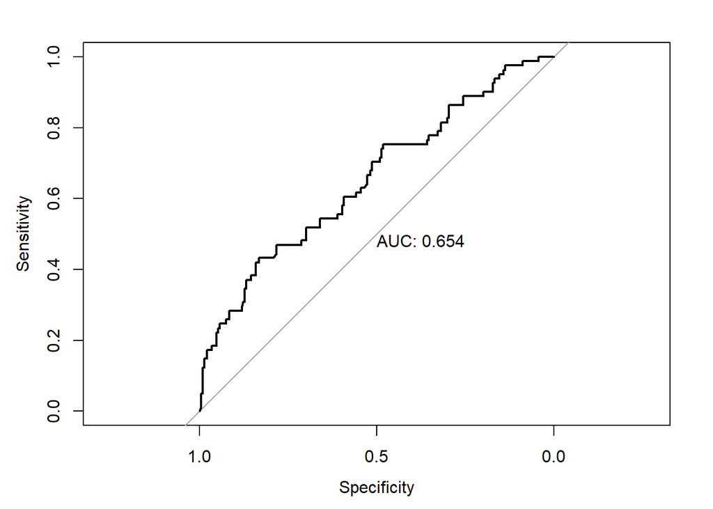

```r
plot.roc(test_set[,8],prob_pred,print.auc=TRUE)
```

```r
results <- cbind(c("Reduced",as.numeric(AIC(classifierFS)),auc(test_set[, 8], yPredFS ),sensitivity,specificity,accuracy))
```

The type=“response” option tells R to ouput probabilities of the form P(Y = 1| X), as opposed to other information such as the logit.

Inorder to predict we must convert these probabilities into class labels, 0 or 1. Hence we use the

yPredFS = ifelse(prob_pred > 0.5, 1,0)

command to create the prediction with 2 levels. Then form the confusion matrix from which we can calculate accuracy and other related values.

For our model, after testing on the test data, below are the CM matrix and other relevant information.

```r
cm
```

```
##    yPredFS
##       0   1
##   0 218   8
##   1  67  14
```

| Variable | $Model 2 |
| --- | --- |
| Type | Reduced |
| NTerms | 3 |
| AIC | 1017.73 |
| AUC | 0.5687 |
| Sensitivity | 0.1728 |
| Specificity | 0.9646 |
| Accuracy | 0.7557 |

##### 4.3 Model Explanation

log ( p(X)/(1 ??? p(X))) = beta0 + beta1X1 + betaX2 + beta3X3 + beta4X4 + beta5X5 + beta6X6

is the model we have built ., The coefficients can be obtained by using the coeff command in R.

p(X)/(1 ??? p(X)) = exp (beta0 + beta1X1 + betaX2 + beta3X3 + beta4X4 + beta5X5 + beta6X6)

can also be called as odds of the bad credit

```r
classifierFS$coefficients
```

```
##   (Intercept)           Age          RESN          RESO          RESP
## -1.477267e+00  2.001923e-02  9.982861e-01  2.497379e-01  1.983049e-01
##          RESU  netFamIncome
##  1.427682e-01 -2.786104e-05
```

p^(X) = e(beta<sup>0+beta</sup>1X) / (1 + e(beta<sup>0+beta</sup>1X))

is the final probability for the response as discussed in the previous section.The type=“response” option tells R to ouput probabilities of the form P(Y = 1| X).

Then the probability of him getting a bad credit is

exp (-1.4772 + 0.02*30 - 2.786x(10^-5)x20000 + 0.998 ) = 0.646

P(bad = 1| X) = ( 0.646/1.646 ) = 0.392

Then the probability of him getting a bad credit is

exp (-1.4772 + 0.02*30 - 2.786*10^-5*50000 + 0.998 ) = 0.2802

P(bad = 1| X) = ( 0.646/1.646 ) = 0.2188

**For increase in income the chance of getting bad credit decreases by 1 time** (exp(-2.79*10^5))

similarly:

**For increase in Age the chance of getting bad credit increase by 1.02 times**(exp(0.02))

##### 4.4 Cross Validation Sets - 10 Fold

Hold out validation can be said as the simplest “kind of cross-validation”, while in k fold cross validation (10 fold here) , we randomly shuffle the dataset into 10 sets d1..d10 , so that all the sets are equal size (this is usually implemented by shuffling the data array and then splitting it in two). We then train on d1+..+d9 and validate on d10, followed by training on d2+..+d10 and validating on d1 ., untill all the sets are used for validation.

If number of observation = k., then it is exacly same as leave-one-out cross-validation

```r
library(caret)
folds = createFolds(training_set$bad, k = 10)
cv = lapply(folds, function(x) {
  training_fold = training_set[-x, ]
  test_fold = training_set[x, ]
  classifierLRM = glm(formula = bad ~ Age+netFamIncome + RES,
                      family = binomial,
                      data = training_set)
  prob_pred = predict(classifierLRM, type = 'response', newdata = test_fold[-8])
  y_pred = ifelse(prob_pred > 0.5, 1, 0)
  cm = table(test_fold[, 8], y_pred > 0.5)
  accuracy = (cm[1,1] + cm[2,2]) / (cm[1,1] + cm[2,2] + cm[1,2] + cm[2,1])
  return(accuracy)
})
accuracyLRM = mean(as.numeric(cv))
print("Accuracy of the Model after 10 Fold Cross- Validation")
```

```
## [1] "Accuracy of the Model after 10 Fold Cross- Validation"
```

```r
accuracyLRM
```

```
## [1] 0.7483516
```

##### 4.5 Visualisation

For the ease of visualisation., i am considering only the 2 variables Age and NetFamilyIncome, for which the performance is more or less same as discussed in the previous sections.

```r
# Visualising the Test set results

vis_test_set <- as.data.frame(cbind(test_set$Age,test_set$netFamIncome,test_set$bad))
vis_train_set <- as.data.frame(cbind(training_set$Age,training_set$netFamIncome,training_set$bad))
classifierFS= glm(formula = bad ~ Age+netFamIncome,
                 family = binomial,
                 data = training_set)

library(ElemStatLearn)
```

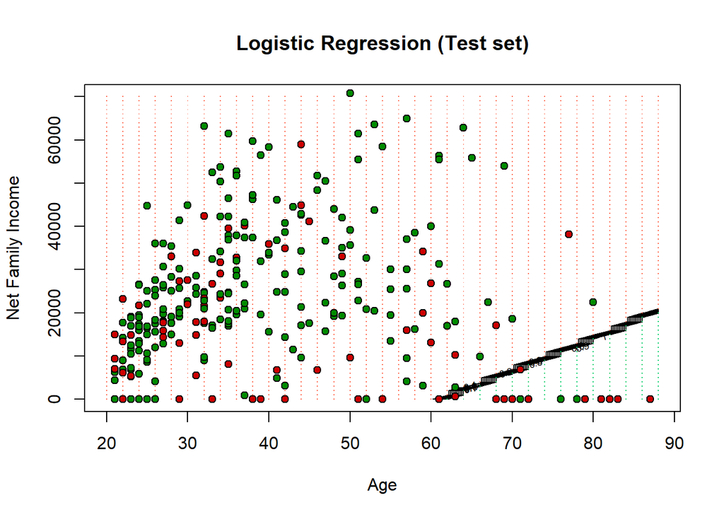

```r
set = vis_test_set
X1 = seq(min(set[, 1]) - 1, max(set[, 1]) + 1, by = 2)
X2 = seq(min(set[, 2]) - 1, max(set[, 2]) + 1, by = 1000)
grid_set = expand.grid(X1, X2)
colnames(grid_set) = c('Age', 'netFamIncome')
prob_set = predict(classifierFS, type = 'response', newdata = grid_set)
y_grid = ifelse(prob_set > 0.5, 1, 0)
plot(set[, -3],
     main = 'Logistic Regression (Test set)',
     xlab = 'Age', ylab = 'Net Family Income',
     xlim = range(X1), ylim = range(X2))
contour(X1, X2, matrix(as.numeric(y_grid), length(X1), length(X2)), add = TRUE)
points(grid_set, pch = '.', col = ifelse(y_grid == 1, 'springgreen3', 'tomato'))
points(set, pch = 21, bg = ifelse(set[, 3] == 1, 'green4', 'red3'))
```

##### 4.6 End Notes

The model is clearly predictiong the zero’s well ., but that is not the case for 1’s/.

Hence Sensitivity = 0.1728 is very low compared to the Specificity = 0.9646 which is very high.

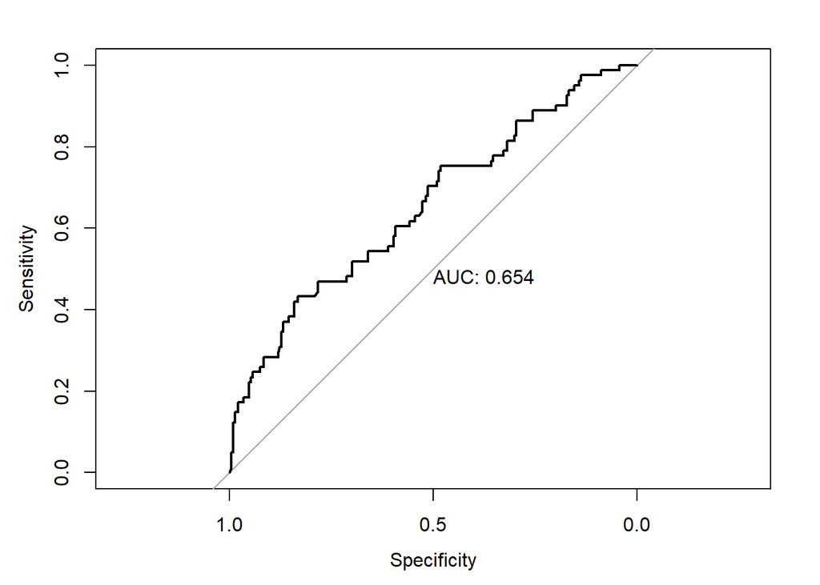

```r
plot.roc(test_set[,8],prob_pred,print.auc=TRUE)
```

According to the ROC of the curve ., for higher sensitivity :

the C = 0 lies in the top right corner c=1 lies in the bottom left corner

hence choosing a value of c = 0.25

```
## [1] "The sensitivity of the model is"
```

[output not shown]

```
## [1] "The accuracy is "
```

```
## [1] 0.64
```

```
## [1] "The Specificity is "
```

```
## [1] 0.678733
```

```
## [1] "The confusion matrix is "
```

[output not shown]